# accuracy_score

**sklearn.metrics.accuracy_score(*y_true*, *y_pred*, *, *normalize=True*, *sample_weight=None*)[[source]](https://github.com/scikit-learn/scikit-learn/blob/cc50648cc/sklearn/metrics/_classification.py#L331)**

Accuracy classification score.

In multilabel classification, this function computes subset accuracy: the set of labels predicted for a sample must *exactly* match the corresponding set of labels in y_true.

Read more in the User Guide.

**Parameters:**

**y_true**1d array-like, or label indicator array / sparse matrix**

Ground truth (correct) labels. Sparse matrix is only supported when labels are of multilabel type.

**y_pred**1d array-like, or label indicator array / sparse matrix**

Predicted labels, as returned by a classifier. Sparse matrix is only supported when labels are of multilabel type.

**normalize**bool, default=True**

If `False`, return the number of correctly classified samples. Otherwise, return the fraction of correctly classified samples.

**sample_weight**array-like of shape (n_samples,), default=None**

Sample weights.

**Returns:**

**score**float**

If `normalize == True`, returns the fraction of correctly classified samples, else returns the number of correctly classified samples.

The best performance is 1.0 with `normalize == True` and the number of samples with `normalize == False`.

See also

**`balanced_accuracy_score`**

Compute the balanced accuracy to deal with imbalanced datasets.

**`jaccard_score`**

Compute the Jaccard similarity coefficient score.

**`hamming_loss`**

Compute the average Hamming loss or Hamming distance between two sets of samples.

**`zero_one_loss`**

Compute the Zero-one classification loss. By default, the function will return the percentage of imperfectly predicted subsets.

#### Examples

```
>>> from sklearn.metrics import accuracy_score
>>> y_pred = [0, 2, 1, 3]
>>> y_true = [0, 1, 2, 3]
>>> accuracy_score(y_true, y_pred)
0.5
>>> accuracy_score(y_true, y_pred, normalize=False)
2.0
```

In the multilabel case with binary label indicators:

```
>>> import numpy as np
>>> accuracy_score(np.array([[0, 1], [1, 1]]), np.ones((2, 2)))
0.5
```

## Gallery examples

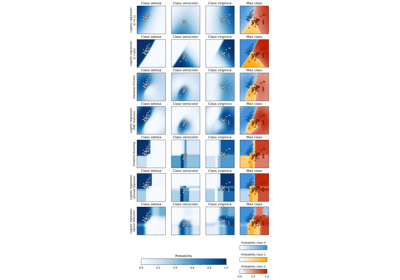

Plot classification probability

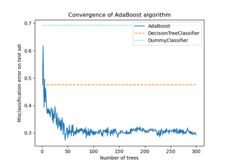

Multi-class AdaBoosted Decision Trees

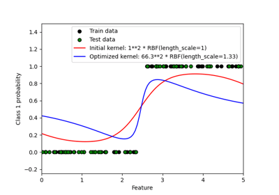

Probabilistic predictions with Gaussian process classification (GPC)

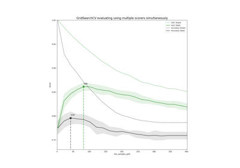

Demonstration of multi-metric evaluation on cross_val_score and GridSearchCV

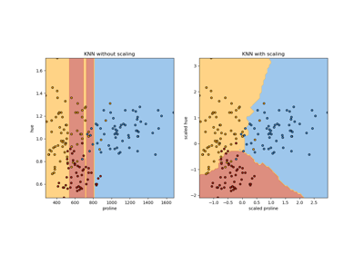

Importance of Feature Scaling

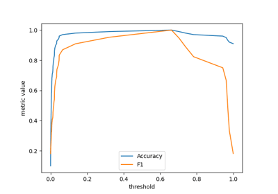

Release Highlights for scikit-learn 1.9

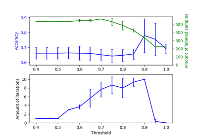

Effect of varying threshold for self-training

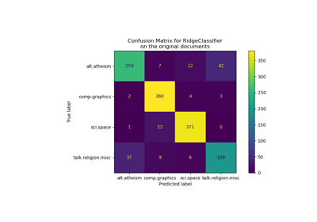

Classification of text documents using sparse features

© 2007–2026 The scikit-learn developers  
Licensed under the 3-clause BSD License.  
https://scikit-learn.org/1.9/modules/generated/sklearn.metrics.accuracy_score.html